# Apêndice 1

### Congruência entre SAD observada e predita

Consideramos que um modelo neutro não foi refutado quando o p-valor for maior ou igual à 5%. Contabilizamos o número de predições não refutadas (Goodness-of-fit) e modelamos a probabilidade de uma predição não ser refutada usando um modelo logito. Agrupamos os dados pelo Sítio de observação (Site). É possível agrupar os dados considerando um intercepto por sítio (1|Site); 1 intercepto por modelo neutro (MN|Site); ou com 1 intercepto e 1 inclinação para k por modelo neutro (k*MN|Site). Na última opção k precisa ser interpretado como variável contínua. Um protocolo de seleção de modelos hierarquicos pode ser encontrado em Zuur et al. 2009 onde se recomenda comparar formas alternativas de agrupar os dados a partir do modelo cheio da relação entre as preditoras. O modelo cheio proposto foi com a interação de terceiro grau entre as preditoras p, k e MN. Comparamos todas as combinações possíveis por verossimilhança [DÚVIDA] se entendo corretamente, os parametros da estrutura aleatória são estimados pelo R2 e os estrutura fixa por algo similar à verossimilhança; ai precisa utilizar o parâmetro REML=TRUE [DÚVIDA]

**Tabela 1** Qual o melhor modelo cheio?

```
##                 dAICc   df weight
## k.f MN|Site         0.0 51 1
## k.z k.z*MN|Site  7857.4 18 <0.001
## k.f 1|Site      13961.6 49 <0.001
## k.z MN|Site     22627.4 11 <0.001
## k.z 1|Site      37264.2 9  <0.001
```

O modelo estatístico com k como fator e agrupamento dos dados como MN|Site foi o único plausível.

**Tabela 2** Qual a relação entre as variáveis é mais plausível?

```
##               dAICc   df weight
## p*k*MN            0.0 51 1
## p*k*MN-p:k:MN  3697.3 40 <0.001
## k*(p+MN)       3701.9 39 <0.001
## MN*(p+k)       6346.6 29 <0.001
## k*MN+p         6352.5 28 <0.001
## k*MN           6357.2 27 <0.001
## p*(k+MN)       7570.3 29 <0.001
## p*k+MN         7577.7 28 <0.001
## p*MN+k        10288.5 18 <0.001
## p+k+MN        10293.1 17 <0.001
## k+MN          10298.7 16 <0.001
## p*MN          23437.1 7  <0.001
## p+MN          23441.9 6  <0.001
## MN            23447.7 5  <0.001
## p*k           36015.1 25 <0.001
## p+k           37721.6 14 <0.001
## k             37725.6 13 <0.001
## p             48819.8 3  <0.001
## 1             48824.0 2  <0.001
```

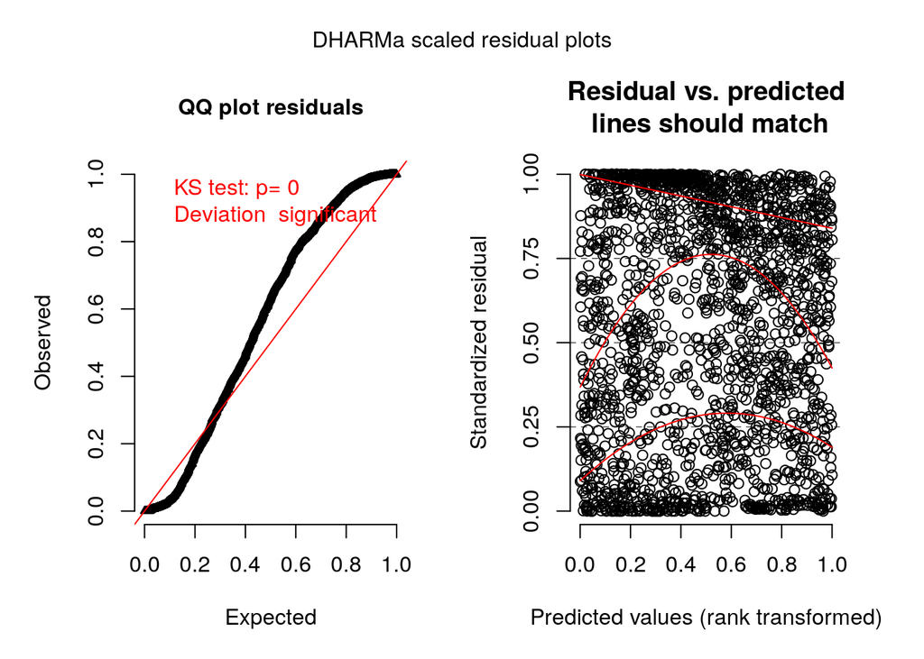

Figura 2. Resíduos quantílicos do modelo mais plaúsivel [aquele que inclui p:k:MN], para detalhes ver documentação da função simulateResiduals.